# Analysis of Open Source Flickr Data in R

David Beskow david.m.beskow.mil@mail.mil

May 2016

## Summary of the Creative Commons 100 Million Flickr Objects Data Set

The Creative Commons is an open source data set of Flickr media objects that Yahoo made available for research. It contains mainly images with some video objects. The raw images and videos are available, as well as metadata files. The data is stored and made available through Amazon Web Services (AWS) S3 storage. Researchers must have a free AWS account to access the data. A summary of the data is given below

- 100 Million media objects (picture and Video)
- Contains objects from 2004 (Flickr inception) through 2014
- 99.2M Photos and 0.8M Video
- Metadata available
- 69M objects contain tags
- ~50% of objects are geotagged
- Available on AWS. See [Yahoo Link](https://webscope.sandbox.yahoo.com/catalog.php?datatype=i&did=67)

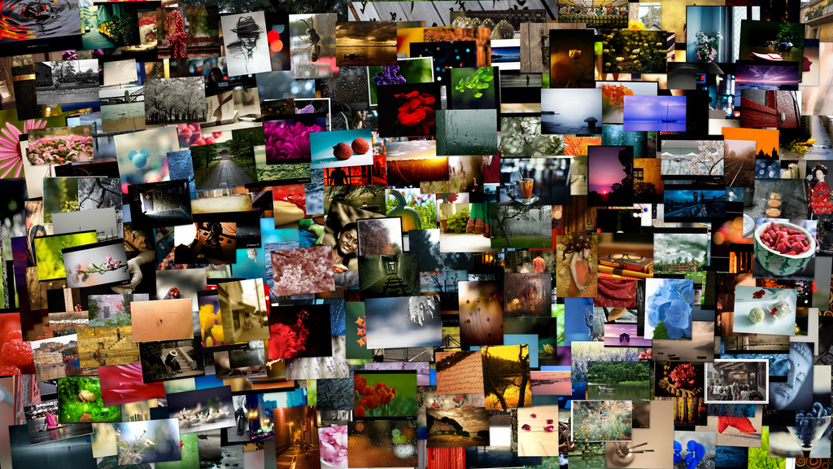

We accessed several subsets of the metadata in order to produce this tutorial. We attempted to select one subset based on location, and one subset based on content. We first queried all media objects that related to Australia (location arbitrarily selected). We then queried one subset that was related to fireworks (type of content again arbitrarily selected). We will use both of these subsets below.

## Explore the Data

First let’s read in the data and clean it up a bit.

```r
library(pointdensityP)
library(raster)
library(ggmap)
library(rgeos)
library(fields)

aus<-read.table("yfcc100m_imgs_vids_australia_eda39a3ee_e_02_15.csv",as.is=TRUE,sep="\t")
aus<-aus[!is.na(aus$V11),]
aus<-subset(aus,select=c(-V9,-V14,-V8,-V7,-V15,-V17,-V16,-V20,-V21,-V23))
names(aus)[grep("V11",names(aus))]<-"lon"
names(aus)[grep("V12",names(aus))]<-"lat"
```

Next we’ll explore the distribution of the data over time:

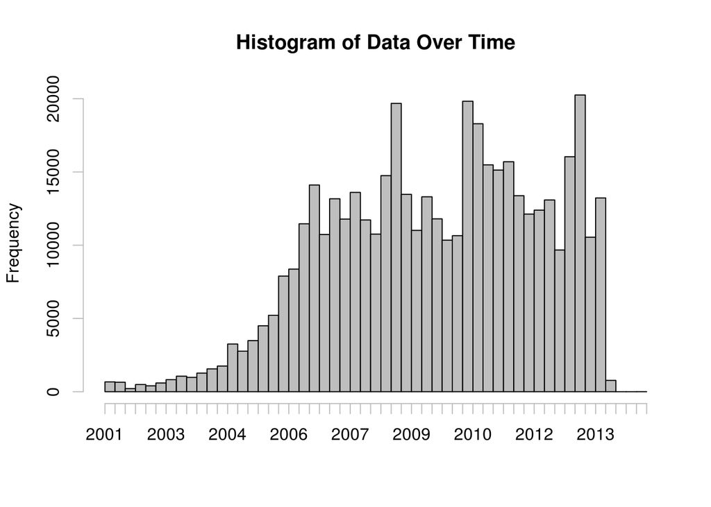

```r
hist(as.POSIXlt(aus$V4,"UTC"),breaks="quarters",
     main="Histogram of Data Over Time",
     freq=TRUE,xlab=NA,col='gray')
```

## Plotting Point Density with *ggmap*

The point density algorithm was originally by Paul Evangelista as a way to visualize military point data. The strength of this visualization is that it presents a density visualization while retaining the granularity of individual points. This algorithm is available in the pointdensityP package on CRAN. We will use this to understand the point data in Australia. Note that in the first two lines of code we remove all of Sydney’s data. If we leave the Sydney data in, it will dominate all other data.

Code for creating Point Density Plot of Australia:

[figure not shown]

Point Density Plot of Australia

[figure not shown]

Point Density Plot of Sydney

```r
distance<-rdist.earth(matrix(c(151.207,-33.86749),ncol=2),as.matrix(aus[,8:9]))
aus.subset<-subset(aus,distance[1,]>30)   ## Remove the Sydney Data
aus.density<-pointdensity(aus.subset,lat_col="lat",lon_col="lon",grid_size=20,radius=50) ##Calculate data density
map_base <- qmap('Australia', zoom = 4, darken=0.2)
map_base + geom_point(aes(x = lon, y = lat, colour = count,alpha=count),
    shape = 16, size = 2, data = aus.density) +
    scale_colour_gradient(low = "yellow", high = "red")
```

Having explored the data, we sat down and considered how we can use this data to answer questions. The two primary questions we came up with are:

- Can I understand movement with this data?
- Can I understand events with this data?

## Creating 8 minute Flickr tracks

The first problem we tried to tackle is to see if we can understand the movement of people with this data. Since the data has a geolocation as well as a time stamp (down to seconds), we can accurately identify a photographers exact location in space and time at discrete intervals. If these locations are close enough in time, we can assume a “track” that the photographer used. Our assumption going into this is that, if we plot “tracks” of photos that are within 8 minutes of each other for all photographers in a given metropolitan area, we will gain an understanding of the movement of people in that area (or at least people who are rapidly taking pictures). To develop this algorithm we first identify our finite list of photographers. We then set up a loop that sequentially creates a temporary subset of data for each photographer, orders this subset by time, and then divides it every time there is a gap of more than 8 minutes between photos. Having divided the subset in such a way, the algorithm would build lines based on the geo location for each of these breaks.

We found that this would be easiest using ggmap, since we could assign a unique group id to each track, and then ggmap would draw them separately.

The figure below is provided to understand the algorithm. In these six data points, we see that the given photographer has a break of greater than 8 minutes between the 3rd and 4th photos. The red line is drawn to indicate that the algorithm would separate this data into two separate “tracks”.

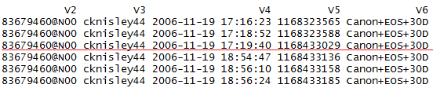

Understanding the Algorithm

Our initial algorithm is below:

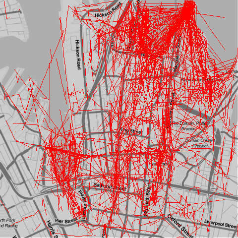

Flickr Tracks

```r
photographers<-unique(sydney$V2)              #ID photographers
final<-list()                                 #Create OJB to store results
for(i in 1:length(photographers)){
temp<-subset(sydney,V2==photographers[i])     #Subset by photographer
temp<-temp[order(temp$V4),]                   #Order by time
breakpoints <- c(FALSE,diff(temp$V4)>8*60)    #Establish break points if diff > 8min
temp$label <- as.numeric(cut.POSIXt(temp$V4, c(min(temp$V4),
              temp[breakpoints, "V4"], max(temp$V4)+1)))    #Convert factor to label
temp$label<-paste(temp$V2,temp$label,sep="")  #Concatenate label with username
final[[i]]<-temp                              #Store temp data
}
final<-do.call("rbind", final)                #Convert from list to dataframe
```

Note that this has many longer tracks that seem to cloud an understanding of people movements. This is presumably cause by photographers who are taking pictures while driving or flying. Since we really wanted to capture pedestrian photographers, we can improve the picture by removing those lines that have a large *bounding box*. This is done in the algorithm below:

```r
count<-1
realFinal<-list()
id<-unique(final$label)
for(i in 1:length(id)){
  temp<-subset(final,label==id[i])
  if(diff(range(temp$lon))<0.004 & diff(range(temp$lat))<0.004){
    realFinal[[count]]<-temp
    count<-count+1
  }
}
realFinal<-do.call("rbind", realFinal)
```

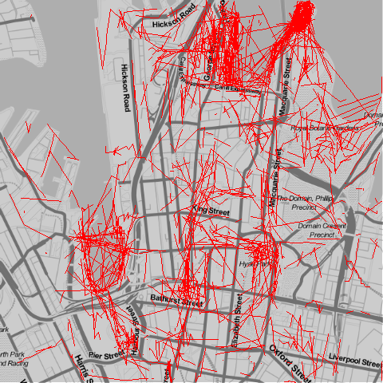

Flickr Tracks

This is more of what we’re looking for, and now have an idea of the paths that pedestrial photographers are taking in downtown Sydney.

## Creating a *leaflet* interactive map

The *leaflet* packages is a great package for creating interactive maps. It is extremely easy to plot point, line, polygon, or raster data on an interactive Open Street map background. Realize that in order to maintain interactivity, this will need to then be tied to an html product. This can be done by exporting the map as an html file, or tying the final product to an RMarkdown document or to a *shiny* web application.

Below is a simple *leaflet* interactive map for displaying the point density data used above.

```r
leaflet(data=sydney) %>%
  addTiles() %>% addMarkers(~lon, ~lat
)
```

[interactive chart not shown]

## Integrating *leaflet* and *shiny*

The *leaflet* package is very powerful when tied together in a *shiny* web application. We did this using the Flickr Fireworks data set in an attempt to help people find the best place to observe fireworks in any city in the world. The web application allows the user to type in a city (which will be geocoded with ggmap) and then the data will be subset so it only includes fireworks images that were geolocated within a user defined radius. The fireworks are then visualized using the point density function. The user has the option to see individual point or to cluster the data. The data points are also tied to a popup which renders the username, camera, and the actual picture. The code for this *shiny* application is given below. The application is available [here](http://data-analytics.net/Apps/fireworks/).

```r
library(shiny)
library(leaflet)
library(RColorBrewer)
library(ggmap)
library(fields)

ui <- bootstrapPage(
  tags$style(type = "text/css", "html, body {width:100%;height:100%}"),
  leafletOutput("map", width = "100%", height = "100%"),
  absolutePanel(top = 10, right = 10,
                textInput("loc", "Location",value = "Sydney, Australia"),
                selectInput("colors", "Color Scheme",
                            rownames(subset(brewer.pal.info, category %in% c("seq", "div"))),
                selected="Reds"),
                sliderInput("dist",label="Radius",min=5,max=50,value=10,step=5),
                checkboxInput("cluster", "Cluster Points", FALSE),
                checkboxInput("legend", "Legend", TRUE),
                submitButton(text = "Apply Changes", icon = NULL, width = NULL)
  )
)

server <- function(input, output, session) {
  load("fire.RData")
  # Reactive expression for the data subsetted to what the user selected

  getGrid <- reactive({
    geocode(input$loc)
  })

  filteredData <- reactive({
    myGrid<-getGrid()
    distance<-rdist.earth(matrix(c(myGrid$lon,myGrid$lat),ncol=2),as.matrix(fire[,c(2,1)]))
    subset(fire,distance[1,]<input$dist)
  })

  # This reactive expression represents the palette function,
  # which changes as the user makes selections in UI.
#   colorpal <- reactive({
#     colorNumeric(input$colors, quakes$mag)
#   })

  colorpal <- reactive({
    colorNumeric(input$colors, fire$count,domain=NULL)
  })

  output$map <- renderLeaflet({
    # Use leaflet() here, and only include aspects of the map that
    # won't need to change dynamically (at least, not unless the
    # entire map is being torn down and recreated).
    leaflet(filteredData()) %>% addTiles()
  })

  # Incremental changes to the map (in this case, replacing the
  # circles when a new color is chosen) should be performed in
  # an observer. Each independent set of things that can change
  # should be managed in its own observer.
  observe({
    data<-filteredData()
    myGrid<-getGrid()
    pal <- colorpal()
    # pal <- colorQuantile("Blues", data$count, n = 6)
    if(input$cluster){
    leafletProxy("map", data = data) %>%
      clearShapes() %>%
      setView(lng<-myGrid$lon,lat=myGrid$lat,zoom=10) %>%
      addCircleMarkers(radius = 2,clusterOptions = markerClusterOptions() #,color=~pal(count),
                 # fillColor = ~pal(count), fillOpacity = 0.7
      )
    }else{
    leafletProxy("map", data = data) %>%
      clearShapes() %>%  clearMarkerClusters() %>%
      setView(lng<-myGrid$lon,lat=myGrid$lat,zoom=10) %>%
      addCircleMarkers(radius = 2 ,color=~pal(count),
                       fillColor = ~pal(count), fillOpacity = 0.7,
                       popup=paste("<figure><img src='",data$pic, "' height='100'></img><figcaption>User: ",data$User,"<br>Camera: ",data$camera,"</figcaption></figure>",sep=""),
                       options=popupOptions(maxWidth=600,minWidth=500)
      )
    }
  })
#
  # Use a separate observer to recreate the legend as needed.
  observe({
    proxy <- leafletProxy("map", data = filteredData())

    # Remove any existing legend, and only if the legend is
    # enabled, create a new one.
    proxy %>% clearControls()
    if (input$legend) {
      pal <- colorpal()
      proxy %>% addLegend(position = "bottomright",
                          pal = pal, values = ~count
      )
    }
  })
}

shinyApp(ui, server)
```